# Statystyka. Regresja - raport

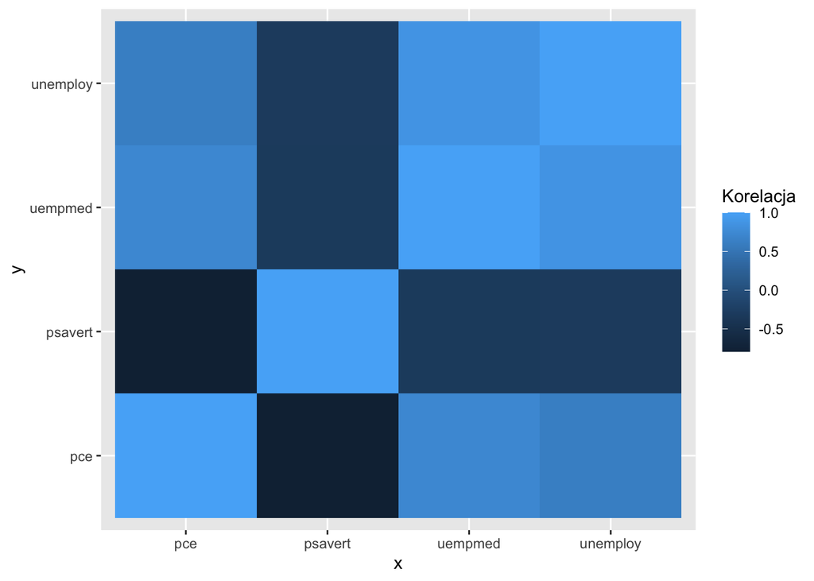

```r
ggplot(econ_cor_matrix_melted, aes(x=x, y=y)) + geom_tile(aes(fill=Korelacja))
```

Warstwa **geom_tile()** służy do rysowania prostokątów, kafelków na wykresie. Wypełniamy prostokątami wartości tam, gdzie jest nasza korelacja. Kolorek jest domyślny oraz skala dobiera się sama w odniesieniu do minimum oraz maksimum ze zbioru danych.

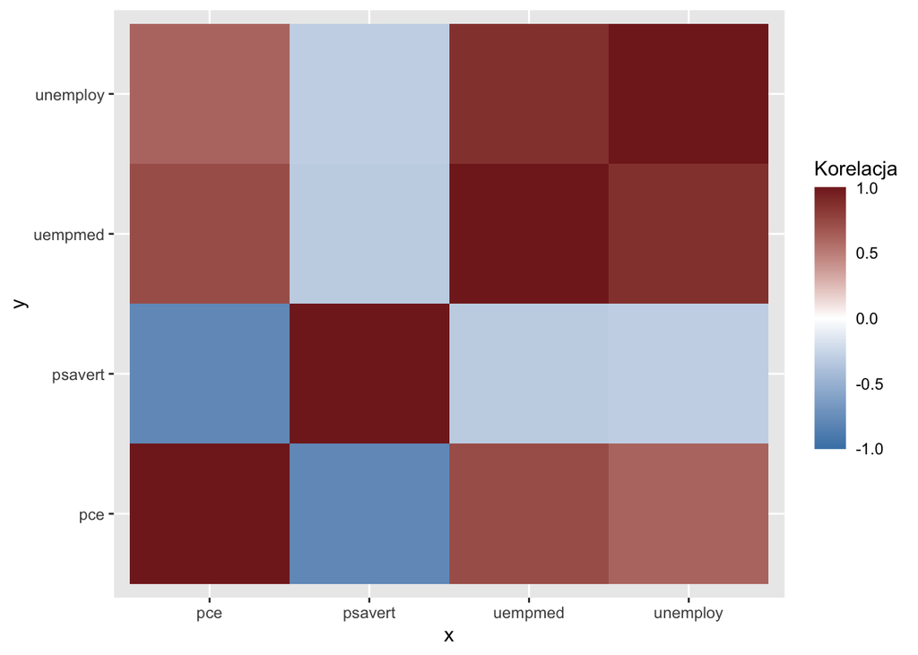

```r
ggplot(econ_cor_matrix_melted, aes(x=x, y=y)) + geom_tile(aes(fill=Korelacja)) + scale_fill_gradient2(low="steelblue", mid="white", high=muted("red"), guide=guide_colorbar(ticks=F, barheight=10), limits=c(-1, 1))
```

Jeszcze ostatnie detale i bedziemy gotowi:

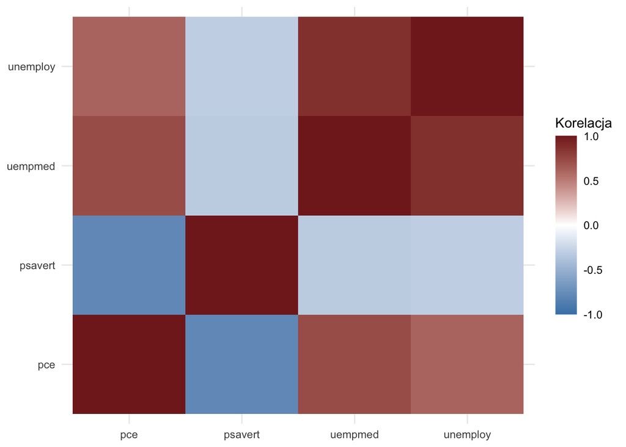

```r
ggplot(econ_cor_matrix_melted, aes(x=x, y=y)) + geom_tile(aes(fill=Korelacja)) + scale_fill_gradient2(low="steelblue", mid="white", high=muted("red"), guide=guide_colorbar(ticks=F, barheight=10), limits=c(-1, 1)) + theme_minimal() + labs(x=NULL, y=NULL)
```

Funkcja **theme_minimal()** jest jedną z funkcji służących do zmiany wyglądu wykresu. Ustawienie stylu theme_minimal() spowoduje, że wykres będzie miał minimalną ilość ozdobników, takich jak ramki czy siatki, co może być użyteczne w przypadku wizualizacji prostych danych.  
Natomiast funkcja **labs()** służy do zmiany etykiet osi na wykresie. W tym przypadku argumenty **x = NULL** i **y = NULL** są użyte do usunięcia etykiet osi x i y odpowiednio. W ten sposób etykiety te zostaną ukryte na wykresie.

### Regresja liniowa

**Regresja liniowa** to metoda statystyczna służąca do określenia liniowej zależności pomiędzy dwoma zmiennymi. Polega ona na znalezieniu takiej linii prostej, która najlepiej “pasuje” do danych i pozwala na przewidywanie wartości jednej zmiennej na podstawie wartości drugiej.

Linia regresji jest obliczana za pomocą równania liniowego $y = a*x + b$, gdzie **y** i **x** to zmienne, a **a** i **b** to współczynniki, które są obliczane na podstawie danych. Współczynnik **a** określa nachylenie linii, a **b** y-intercept, czyli miejsce, w którym linia przecina oś 0y.  
Przykład:

```r
liczba_studentow_AGH = c(4000, 12000, 6000, 21000, 9000, 1000, 3000)
powierzchnia_sal_dydaktycznych = c(4500, 8800, 4200, 17000, 6000, 1800, 2500)

modelYX = lm(formula = liczba_studentow_AGH ~ powierzchnia_sal_dydaktycznych)
modelYX
```

```
##
## Call:
## lm(formula = liczba_studentow_AGH ~ powierzchnia_sal_dydaktycznych)
##
## Coefficients:
##                    (Intercept)  powierzchnia_sal_dydaktycznych
##                       -267.811                           1.292
```

```r
modelXY = lm(formula = powierzchnia_sal_dydaktycznych ~ liczba_studentow_AGH)
modelXY
```

```
##
## Call:
## lm(formula = powierzchnia_sal_dydaktycznych ~ liczba_studentow_AGH)
##
## Coefficients:
##          (Intercept)  liczba_studentow_AGH
##             380.0000                0.7525
```

```r
a1 <- modelYX$coefficients[2]
a0 <- modelYX$coefficients[1]
b1 <- modelXY$coefficients[2]
b0 <- modelXY$coefficients[1]

names(a1) = NULL
names(a0) = NULL
names(b1) = NULL
names(a0) = NULL

sqrt(a1*b1)
```

```
## [1] 0.9859583
```

```r
cor(liczba_studentow_AGH, powierzchnia_sal_dydaktycznych)
```

```
## [1] 0.9859583
```

```r
cor(powierzchnia_sal_dydaktycznych, liczba_studentow_AGH)
```

```
## [1] 0.9859583
```

Jak widać, obliczenia się zgadzają. Do wyliczania regresji liniowej w R służy funkcja **lm()**.  
Kolejny przykład. Teraz korzystamy ze zbioru father.son:

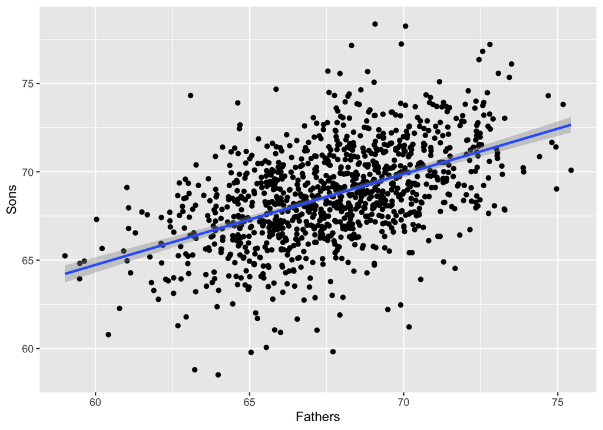

```r
data(father.son, package='UsingR')
ggplot(father.son, aes(x=fheight, y=sheight)) + geom_point() + geom_smooth(method="lm") + labs(x="Fathers", y="Sons")
```

Tym razem dzięki warstwie **geom_point()** dostaliśmy wykres punktówy, zamiast kafelkowej mapy ciepła. Funkcja **geom_smooth()** jest używana do dodawania gładkiej krzywej do wykresu. Argument **method** określa metodę użytą do obliczenia gładkiej krzywej. Domyślną metodą jest “loess”, która dopasowuje lokalną regresję wielomianową. Metoda “lm” dopasowuje model liniowy do danych.

```r
heightsLM <- lm(sheight ~ fheight, data=father.son)
heightsLM
```

```
##
## Call:
## lm(formula = sheight ~ fheight, data = father.son)
##
## Coefficients:
## (Intercept)      fheight
##     33.8866       0.5141
```

Jak widać, na rysunku możemy zaobserwować zarówno współczynnik **b**, jak i **a**. Skoro nachylenie to +/- 0.5, to na każdy cal wzrostu ojca przypadnie pół cala wzrostu syna (statystycznie).  
Zobaczmy pełny raport zbioru ojców i synów:

```r
summary(heightsLM)
```

```
##
## Call:
## lm(formula = sheight ~ fheight, data = father.son)
##
## Residuals:
##     Min      1Q  Median      3Q     Max
## -8.8772 -1.5144 -0.0079  1.6285  8.9685
##
## Coefficients:
##             Estimate Std. Error t value Pr(>|t|)
## (Intercept) 33.88660    1.83235   18.49   <2e-16 ***
## fheight      0.51409    0.02705   19.01   <2e-16 ***
## ---
## Signif. codes:  0 '***' 0.001 '**' 0.01 '*' 0.05 '.' 0.1 ' ' 1
##
## Residual standard error: 2.437 on 1076 degrees of freedom
## Multiple R-squared:  0.2513, Adjusted R-squared:  0.2506
## F-statistic: 361.2 on 1 and 1076 DF,  p-value: < 2.2e-16
```

### Histogramy

To wykres danych dla jednej zmiennej prezentujący rozkład wartości tej zmiennej. Przykład:

```r
data("diamonds")
head(diamonds)
```

```
## # A tibble: 6 × 10
##   carat cut       color clarity depth table price     x     y     z
##   <dbl> <ord>     <ord> <ord>   <dbl> <dbl> <int> <dbl> <dbl> <dbl>
## 1  0.23 Ideal     E     SI2      61.5    55   326  3.95  3.98  2.43
## 2  0.21 Premium   E     SI1      59.8    61   326  3.89  3.84  2.31
## 3  0.23 Good      E     VS1      56.9    65   327  4.05  4.07  2.31
## 4  0.29 Premium   I     VS2      62.4    58   334  4.2   4.23  2.63
## 5  0.31 Good      J     SI2      63.3    58   335  4.34  4.35  2.75
## 6  0.24 Very Good J     VVS2     62.8    57   336  3.94  3.96  2.48
```

Oczywiście wykorzystamy gotową funkcję **hist()**:

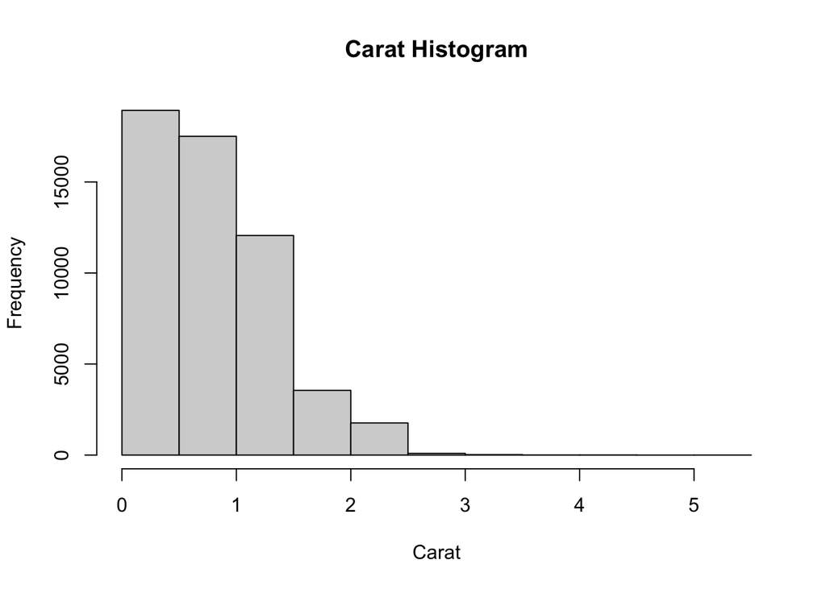

```r
hist(diamonds$carat, main="Carat Histogram", xlab="Carat")
```

Wykres pokazuje rozkład (dystrybucję) rozmiarów w karatach.  
Histogram dzieli dane na zakresy (koszyki), wysokość słupków reprezentuje liczbę obserwacji trafiających do każdego koszyka.

#### Wykres punktowy

Scatter plot (ang.) – punkt wykresu reprezentuje obserwacje z dwiema zmiennymi, przy czym oś x reprezentuje jedną zmienną, zaś oś y – drugą zmienną.

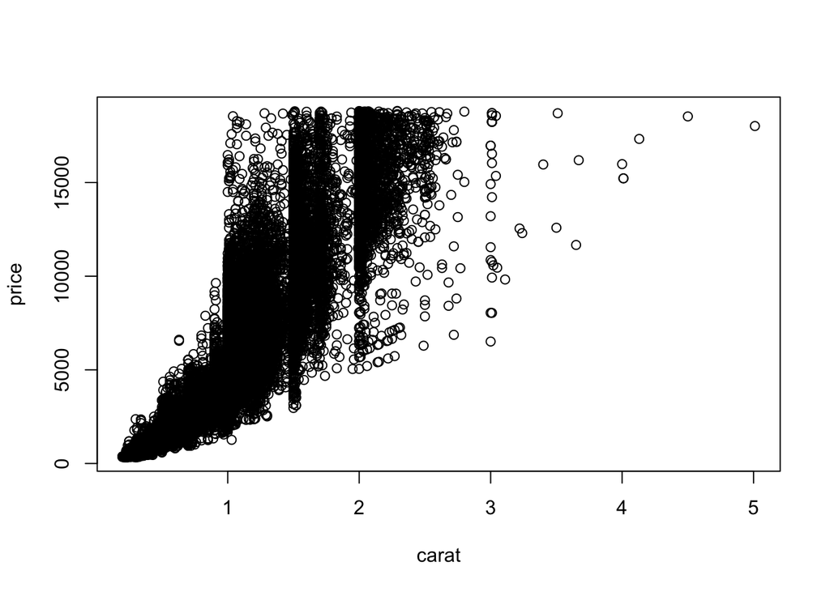

```r
plot(price~carat, data=diamonds)
```